# 回帰分析②

更新：2026/10/07

目次に * が付いている箇所は授業では時間があれば紹介する。

## 1. 分析例：ポアソン回帰

### データ

**オーストラリアの病院通院（受診）回数調査データ（data_visit.csv）**

- 観測期間：1977–1978
- サンプル数：5190人

| visits | gender | age | income |
| --- | --- | --- | --- |
| 1 | female | 0.19 | 0.55 |
| 1 | female | 0.19 | 0.45 |
| 1 | male | 0.19 | 0.90 |
| 1 | male | 0.19 | 0.15 |
| 1 | male | 0.19 | 0.45 |
| 1 | female | 0.19 | 0.35 |

| 変数名 | 内容 |
| --- | --- |
| visits ($y$) | 過去2週間の受診回数 |
| gender ($x_1$) | 性別（female = 女性，male = 男性） |
| age ($x_2$) | 年齢（スケール調整のため単位は年齢 ÷ 100） |
| Income ($x_3$) | 年収（単位：万ドル） |

**データ出典** ： AER パッケージの DoctorVisits データ（実習用に一部変更）

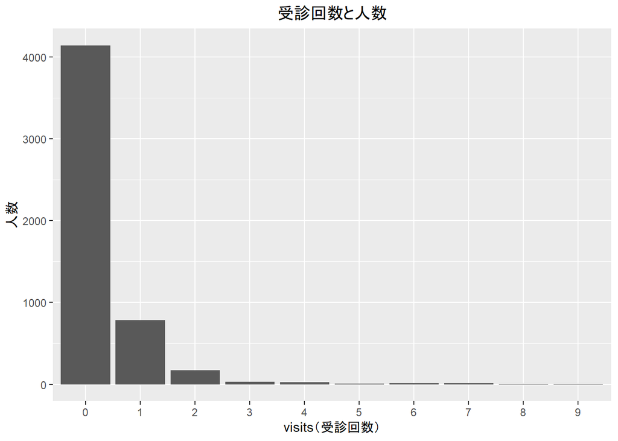

**作図Rコード（クリックで表示）**

```r
library(tidyverse)

data_visit %>%
  mutate(visits = as.factor(visits)) %>%
  count(visits, name = "n") %>%
  ggplot(aes(x = visits, y = n)) +
  geom_bar(stat = "identity") +
  labs(title = "受診回数と人数", x = "visits（受診回数）", y = "人数") +
  theme(
    plot.title = element_text(hjust = 0.5)
  )
```

### モデル

$$y \sim Poisson(\lambda)$$

$$\log(\lambda) = \beta_0 + \beta_1x_1 + \beta_2x_2 + \beta_3x_3 +
\beta_4x_1x_2$$

- $\lambda$ は期待値（平均）かつ分散パラメータで $\lambda>0$
- 回帰モデルの最後の項 $x_1x_2$ は gender × age の交差項

ポアソン分布のパラメータは $\lambda>0$ の制約がある。 回帰モデルの右辺 $\beta_0 + \beta_1x_1 + \beta_2x_2 + \beta_3x_3 + \beta_4x_1x_2$ は回帰係数 $\beta$ の符号によってはプラスではなくマイナスの値になることもあるので，左辺の目的変数もプラス・マイナス両方の値がとれるように対数変換をした $\log(\lambda)$ を目的変数としてモデル化する（対数リンクまたはlogリンク）。

**補足**：0以上1未満の数値の対数変換と負の数値の指数変換

- $\log(2) = 0.693$
- $\log(0.5) = \log(2^{-1}) = -\log(2) = -0.693$
- $\exp(-2) = e^{-2}=\left(\frac{1}{e}\right)^2 = 0.135$
- $\log(\exp(a)) = \log_e e^a = a$

### Rコード

```r
# データの読み込み
data_visit <- read.csv("data/data_visit.csv")

# ポアソン回帰の実行
result <- glm(visits ~ gender + age + income + gender:age, family = poisson, data = data_visit)

# 推定結果の表示
summary(result)

# 回帰係数の倍率
exp(coef(result))
```

**`glm(formula, family, data)`：一般化線形モデルの推定**

- **`formula`**：目的変数・説明変数の指定
- **`family`**：確率分布の指定 ⇒ ポアソン回帰の場合は `family = poisson`
- **`data`**：分析データの指定

**補足**：

- `formula`の説明変数に文字のみの列を指定すると自動でダミー変数に変換してくれる（上記例では gender 列）
- `formula`内の `:` で説明変数変数の交差項を追加できる（上記例では $x_1x_2$ の gender × age）

#### Rコードの出力

```
##
## Call:
## glm(formula = visits ~ gender + age + income + gender:age, family = poisson,
##     data = data_visit)
##
## Coefficients:
##                Estimate Std. Error z value Pr(>|z|)
## (Intercept)    -1.25697    0.09959 -12.621  < 2e-16 ***
## gendermale     -0.77056    0.12664  -6.085 1.17e-09 ***
## age             0.77965    0.15750   4.950 7.42e-07 ***
## income         -0.29323    0.07942  -3.692 0.000222 ***
## gendermale:age  1.24868    0.25309   4.934 8.07e-07 ***
## ---
## Signif. codes:  0 '***' 0.001 '**' 0.01 '*' 0.05 '.' 0.1 ' ' 1
##
## (Dispersion parameter for poisson family taken to be 1)
##
##     Null deviance: 5634.8  on 5189  degrees of freedom
## Residual deviance: 5410.9  on 5185  degrees of freedom
## AIC: 7752.5
##
## Number of Fisher Scoring iterations: 6
```

```
##    (Intercept)     gendermale            age         income gendermale:age
##      0.2845150      0.4627543      2.1807169      0.7458531      3.4857551
```

### 推定結果

|  | 回帰係数 | exp(回帰係数) | 標準誤差 | t 値 | p 値 |
| --- | --- | --- | --- | --- | --- |
| (Intercept) | -1.257 | 0.285 | 0.100 | -12.621 | 0 |
| gendermale | -0.771 | 0.463 | 0.127 | -6.085 | 0 |
| age | 0.780 | 2.181 | 0.158 | 4.950 | 0 |
| income | -0.293 | 0.746 | 0.079 | -3.692 | 0 |
| gendermale:age | 1.249 | 3.486 | 0.253 | 4.934 | 0 |

- age の係数 $\beta_2$ より，年齢が高いほど受診回数が多い
- income の係数 $\beta_3$ より，収入が多いほど受診回数が少ない
- gendermale の係数 $\beta_1$ より，男性は女性に比べて受診回数が少ない
- ただし，gendermale:age（性別ダミーと年齢の交差項）の係数 $\beta_4$ より，男性は女性よりも加齢による受診回数の増加率が大きい

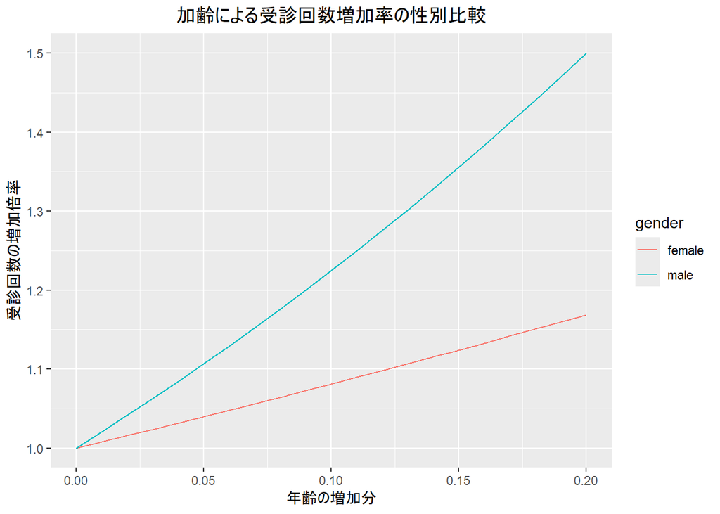

**作図Rコード（クリックで表示）**

```r
coef_age <- coef(result)["age"]
coef_genage <- coef(result)["gendermale:age"]

df <- data.frame(age = seq(0, 0.2, 0.01)) %>%
  mutate(
    female = exp(coef_age * age),
    male = exp((coef_age + coef_genage) * age)
  ) %>%
  pivot_longer(
    cols = c(female, male),
    names_to = "gender",
    values_to = "scale"
  )

df %>%
  ggplot() +
  geom_line(aes(x = age, y = scale, colour = gender)) +
  labs(title = "加齢による受診回数増加率の性別比較", x = "年齢の増加分", y = "受診回数の増加倍率") +
    theme(
    plot.title = element_text(hjust = 0.5),
    legend.position = "right"
  )
```

### ゼロ過剰モデル*

カウントデータの中には観測値にゼロが多いケースがある。 ゼロ過剰モデルは，$y = 0$ かどうかを推定するロジスティック回帰と，$y \ge 0$ の場合のカウントデータモデル（ポアソン回帰または負の二項回帰）を組み合わせた手法である。

```r
# パッケージのインストールと読み込み
# install.packages("pscl")  # 初回のみ実行
library(pscl)

# ゼロ過剰ポアソンモデルの推定
result_zip <- zeroinfl(visits ~ gender + age + income + gender:age | gender + age + income + gender:age,
                       data = data_visit, dist = "poisson")

# 推定結果の表示
summary(result_zip)

# 通常モデルとのAIC・BICの比較
AIC(result, result_zip)
BIC(result, result_zip)
```

**`zeroinfl(formula, data, dist)`：ゼロ過剰モデルの推定**

- **`formula`**：目的変数・説明変数の指定
  - 説明変数は `|` の左側にカウントデータモデルの説明変数，右側にロジスティック回帰モデルの説明変数を指定
- **`data`**：分析データの指定
- **`dist`**：確率分布の指定 ⇒ ポアソン回帰の場合は `dist = "poisson"`

#### Rコードの出力

```
## # 推定結果の表示
##
## Call:
## zeroinfl(formula = visits ~ gender + age + income + gender:age | gender +
##     age + income + gender:age, data = data_visit, dist = "poisson")
##
## Pearson residuals:
##     Min      1Q  Median      3Q     Max
## -0.5762 -0.4853 -0.3857 -0.3102 13.1473
##
## Count model coefficients (poisson with log link):
##                Estimate Std. Error z value Pr(>|z|)
## (Intercept)     0.07879    0.16583   0.475 0.634705
## gendermale     -0.01101    0.20440  -0.054 0.957046
## age            -0.10519    0.25957  -0.405 0.685303
## income         -0.46337    0.13823  -3.352 0.000802 ***
## gendermale:age  0.34860    0.39340   0.886 0.375554
##
## Zero-inflation model coefficients (binomial with logit link):
##                Estimate Std. Error z value Pr(>|z|)
## (Intercept)      1.0831     0.2379   4.553 5.28e-06 ***
## gendermale       1.0106     0.2772   3.645 0.000267 ***
## age             -1.5102     0.4064  -3.716 0.000202 ***
## income          -0.2491     0.2008  -1.241 0.214774
## gendermale:age  -1.0637     0.5892  -1.805 0.071019 .
## ---
## Signif. codes:  0 '***' 0.001 '**' 0.01 '*' 0.05 '.' 0.1 ' ' 1
##
## Number of iterations in BFGS optimization: 19
## Log-likelihood: -3625 on 10 Df
##
## # 通常モデルとのAIC・BICの比較
##            df      AIC
## result      5 7752.516
## result_zip 10 7270.996
##            df      BIC
## result      5 7785.288
## result_zip 10 7336.540
```

- `Count model coefficients (poisson with log link)`：ポアソン回帰の推定値
- `Zero-inflation model coefficients (binomial with logit link)` ：ロジスティック回帰の推定値
  - ロジスティック回帰の係数推定値はプラスで有意なら，$y = 0$ となる確率が高まることを意味する

## 2. 分析例：負の二項回帰*

### モデル

$$y \sim NB(\mu, \theta)$$
$$\log(\mu) = \beta_0 + \beta_1x_1 + \beta_2x_2 + \beta_3x_3 +
\beta_4x_1x_2$$

- $\mu$ は期待値（平均），$\theta$ はサイズパラメータ
- $\mu > 0$ の制約があるためポアソン回帰と同じく，対数変換した $\mu$ を目的変数とした回帰モデルで推定する
- 負の二項分布のパラメータには「期待値 $<$ 分散」の関係があるため，期待値より分散が大きいデータに対応できる

### Rコード

```r
# パッケージのインストールと読み込み
# install.packages("MASS")  # 初回のみ実行
library(MASS)

# 負の二項回帰の実行
result_nb <- glm.nb(visits ~ gender + age + income + gender:age, data = data_visit)

# 推定結果の表示
summary(result_nb)

# ポアソン回帰とのAIC・BICの比較
AIC(result, result_nb)
BIC(result, result_nb)
```

**`glm.nb(formula, data)`：負の二項回帰モデルの推定**

#### Rコードの出力

```
## # 推定結果の表示
##
## Call:
## glm.nb(formula = visits ~ gender + age + income + gender:age,
##     data = data_visit, init.theta = 0.4341567311, link = log)
##
## Coefficients:
##                Estimate Std. Error z value Pr(>|z|)
## (Intercept)     -1.2770     0.1298  -9.835  < 2e-16 ***
## gendermale      -0.7665     0.1600  -4.791 1.66e-06 ***
## age              0.7974     0.2114   3.771 0.000162 ***
## income          -0.2685     0.1011  -2.655 0.007926 **
## gendermale:age   1.2302     0.3383   3.636 0.000277 ***
## ---
## Signif. codes:  0 '***' 0.001 '**' 0.01 '*' 0.05 '.' 0.1 ' ' 1
##
## (Dispersion parameter for Negative Binomial(0.4342) family taken to be 1)
##
##     Null deviance: 3125.6  on 5189  degrees of freedom
## Residual deviance: 2993.2  on 5185  degrees of freedom
## AIC: 7055.4
##
## Number of Fisher Scoring iterations: 1
##
##
##               Theta:  0.4342
##           Std. Err.:  0.0318
##
##  2 x log-likelihood:  -7043.3810
##
## # ポアソン回帰とのAIC・BICの比較
##           df      AIC
## result     5 7752.516
## result_nb  6 7055.381
##           df      BIC
## result     5 7785.288
## result_nb  6 7094.708
```

## 3. データ分析実習

### データ

**商品Aの日時販売点数データ**（count_data.csv）

- サンプル数：361日間

| TID | y | x1 | x2 | x3 | x4 | x5 | x6 | k |
| --- | --- | --- | --- | --- | --- | --- | --- | --- |
| 1 | 1 | 1 | 0 | 0 | 0.8989899 | 0 | 0 | 3450 |
| 2 | 1 | 1 | 0 | 0 | 0.8989899 | 0 | 0 | 3364 |
| 3 | 1 | 1 | 0 | 0 | 0.8989899 | 0 | 0 | 3699 |
| 4 | 1 | 1 | 0 | 0 | 0.8860029 | 0 | 0 | 4101 |
| 5 | 1 | 1 | 0 | 0 | 0.8989899 | 0 | 0 | 3045 |
| 6 | 0 | 1 | 0 | 0 | 0.8989899 | 0 | 0 | 3344 |

| 変数 | 内容 |
| --- | --- |
| TID | 時点（単位：1日） |
| y | 商品Aの販売点数 |
| x1 | 商品Aの価格掛率 |
| x2 | 商品Aのエンド（ダミー変数） |
| x3 | 商品Aのチラシ（ダミー変数） |
| x4 | 商品B（競合）の価格掛率 |
| x5 | 商品B（競合）のエンド（ダミー変数） |
| x6 | 商品B（競合）のチラシ（ダミー変数） |
| k | 当日の来店客数 |

**データ出典** ： 照井・佐藤（2022）「現代マーケティング・リサーチ（新版）」有斐閣，第16章

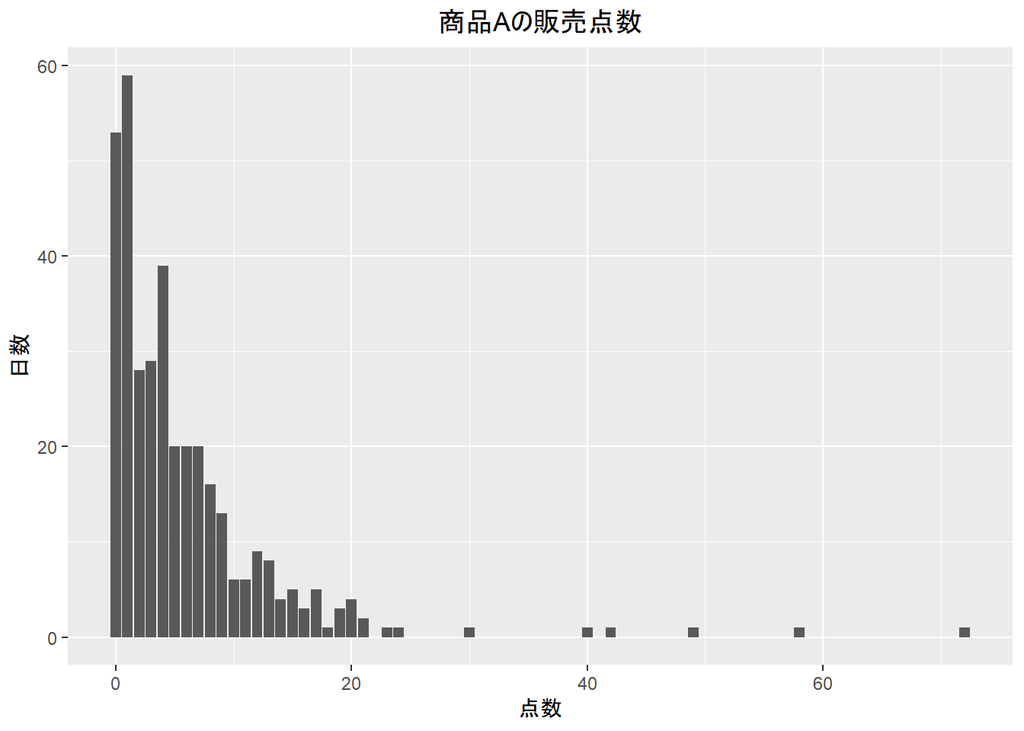

**作図Rコード（クリックで表示）**

```r
df <- count_data %>%
  count(y, name = "n") %>%
  complete(y = 0:max(y), fill = list(n = 0))

df %>%
  ggplot(aes(x = y, y = n)) +
  geom_bar(stat = "identity") +
  labs(title = "商品Aの販売点数", x = "点数", y = "日数") +
  theme(
    plot.title = element_text(hjust = 0.5)
  )
```

### 課題

以下のオフセット項を含むポアソン回帰モデルで，回帰係数 ($\beta_0, \beta_1, \dots, \beta_6$) を推定し，各説明変数の目的変数への影響を考察せよ。

#### モデル

$$y \sim Poisson(\lambda)$$

$$\log(\lambda) = \log(k) + \beta_0 + \sum_{k=1}^6 \beta_k x_k \\
\text{or} \quad \lambda = k\exp\left(\beta_0 + \sum_{k=1}^6 \beta_k
x_k\right)$$

**目的変数**：販売点数（y）  
**説明変数**：自己の価格掛率・エンド・チラシ（x1, x2, x3）と競合の価格掛率・エンド・チラシ（x4, x5, x6）

来店客数 k はオフセット項として利用する。 Rの実行コードではオフセット項を含むモデルは  
`glm(y ~ x, family, data, offset = log(k))`  
のように，`glm` 関数の引数に `offset = log(k)` を追加することで実行できる（`y ~ x, family, data` 部分は本課題のモデル・データに合わせて変更が必要）。

**Rコード（クリックで表示）**

```r
# データの読み込み
count_data <- read.csv("data/count_data.csv")

# オフセット項ありポアソン回帰の実行
result <- glm(y ~ x1 + x2 + x3 + x4 + x5 + x6, family = poisson, data = count_data, offset = log(k))

# 推定結果の表示
summary(result)

# 回帰係数の倍率
exp(coef(result))

#（参考1）価格掛率の影響 = exp(価格係数 * -割引率)
exp(-4.08155 * -0.05) # 自己価格5%引き
exp(3.71043 * -0.1)   # 競合価格10%引き

#（参考2）オフセット項なしモデルとの比較
result_no.offset <- glm(y ~ x1 + x2 + x3 + x4 + x5 + x6, family = poisson, data = count_data)
summary(result_no.offset)

AIC(result, result_no.offset)
BIC(result, result_no.offset)
```